# R Notebook

INFERENTIAL MODELLING – HDS 5320-02 ASSIGNMENT – 06 (WEEK-06) Vaishnavi Gannavaram Instructor : Dr. Srikanth Mudigonda —

```r
install.packages("MatchIt")
install.packages("optmatch")
```

```r
#Q1 Loading the dataset from package
require("faraway")
data("pima")
```

```r
#checking the summary
summary(pima)
```

```
    pregnant         glucose        diastolic
 Min.   : 0.000   Min.   :  0.0   Min.   :  0.00
 1st Qu.: 1.000   1st Qu.: 99.0   1st Qu.: 62.00
 Median : 3.000   Median :117.0   Median : 72.00
 Mean   : 3.845   Mean   :120.9   Mean   : 69.11
 3rd Qu.: 6.000   3rd Qu.:140.2   3rd Qu.: 80.00
 Max.   :17.000   Max.   :199.0   Max.   :122.00
    triceps         insulin           bmi           diabetes
 Min.   : 0.00   Min.   :  0.0   Min.   : 0.00   Min.   :0.0780
 1st Qu.: 0.00   1st Qu.:  0.0   1st Qu.:27.30   1st Qu.:0.2437
 Median :23.00   Median : 30.5   Median :32.00   Median :0.3725
 Mean   :20.54   Mean   : 79.8   Mean   :31.99   Mean   :0.4719
 3rd Qu.:32.00   3rd Qu.:127.2   3rd Qu.:36.60   3rd Qu.:0.6262
 Max.   :99.00   Max.   :846.0   Max.   :67.10   Max.   :2.4200
      age             test
 Min.   :21.00   Min.   :0.000
 1st Qu.:24.00   1st Qu.:0.000
 Median :29.00   Median :0.000
 Mean   :33.24   Mean   :0.349
 3rd Qu.:41.00   3rd Qu.:1.000
 Max.   :81.00   Max.   :1.000
```

```r
??pima
```

```r
View(pima)
```

```r
#Q2 . building full model using all predictors and outcome variable test to check relationship and then formulating the question.
lmod.full <- glm(pima$test ~ pregnant  +glucose + diastolic+ triceps+ insulin + bmi+ diabetes+ age , family = binomial, data = pima)
summary(lmod.full)
```

```
Call:
glm(formula = pima$test ~ pregnant + glucose + diastolic + triceps +
    insulin + bmi + diabetes + age, family = binomial, data = pima)

Deviance Residuals:
    Min       1Q   Median       3Q      Max
-2.5566  -0.7274  -0.4159   0.7267   2.9297

Coefficients:
              Estimate Std. Error z value Pr(>|z|)
(Intercept) -8.4046964  0.7166359 -11.728  < 2e-16 ***
pregnant     0.1231823  0.0320776   3.840 0.000123 ***
glucose      0.0351637  0.0037087   9.481  < 2e-16 ***
diastolic   -0.0132955  0.0052336  -2.540 0.011072 *
triceps      0.0006190  0.0068994   0.090 0.928515
insulin     -0.0011917  0.0009012  -1.322 0.186065
bmi          0.0897010  0.0150876   5.945 2.76e-09 ***
diabetes     0.9451797  0.2991475   3.160 0.001580 **
age          0.0148690  0.0093348   1.593 0.111192
---
Signif. codes:  0 ‘***’ 0.001 ‘**’ 0.01 ‘*’ 0.05 ‘.’ 0.1 ‘ ’ 1

(Dispersion parameter for binomial family taken to be 1)

    Null deviance: 993.48  on 767  degrees of freedom
Residual deviance: 723.45  on 759  degrees of freedom
AIC: 741.45

Number of Fisher Scoring iterations: 5
```

#Based on each predictor’s coefficients p values, predictors “pregnant”,“glucose”,“diastolic”,“bmi”,“diabetes” have significant relationship with the outcome variable.

## Pima test.lmod.full = -8.40 + 0.12*pregnant + 0.03*glucose - 0.01*diastolic + 0.09*bmi +0.94*diabetes

Formulating research question

Does the presence of “test” variable affect the glucose levels, Considering the “diabetes”, “BMI”, “pregnant” as predictors.

## Inorder to find out that , we are using “test” variable as treatment/controlled variable and glucose level as outcome variable with predictors bmi, diabetes, and pregnant.

```r
#Q3
#nearest method
library(MatchIt)
m.out1 <- matchit(test ~ bmi+diabetes+pregnant,
                 data = pima,
                 method="nearest")
summary(m.out1)
```

```
Call:
matchit(formula = test ~ bmi + diabetes + pregnant, data = pima,
    method = "nearest")

Summary of Balance for All Data:
         Means Treated Means Control Std. Mean Diff. Var. Ratio
distance        0.4521        0.2937          0.8208     1.3711
bmi            35.1425       30.3042          0.6662     0.8921
diabetes        0.5505        0.4297          0.3243     1.5500
pregnant        4.8657        3.2980          0.4190     1.5375
         eCDF Mean eCDF Max
distance    0.2380   0.3568
bmi         0.1575   0.3126
diabetes    0.1042   0.1701
pregnant    0.0920   0.2065


Summary of Balance for Matched Data:
         Means Treated Means Control Std. Mean Diff. Var. Ratio
distance        0.4521        0.3989          0.2758     1.6598
bmi            35.1425       33.9354          0.1662     1.1472
diabetes        0.5505        0.5040          0.1248     1.1909
pregnant        4.8657        4.3358          0.1416     1.2230
         eCDF Mean eCDF Max Std. Pair Dist.
distance    0.0509   0.1604          0.2762
bmi         0.0355   0.0784          0.7898
diabetes    0.0363   0.0896          0.9432
pregnant    0.0353   0.1082          0.9076

Sample Sizes:
          Control Treated
All           500     268
Matched       268     268
Unmatched     232       0
Discarded       0       0
```

```
[1] "To identify the units, use first mouse button; to stop, use second."
integer(0)
```

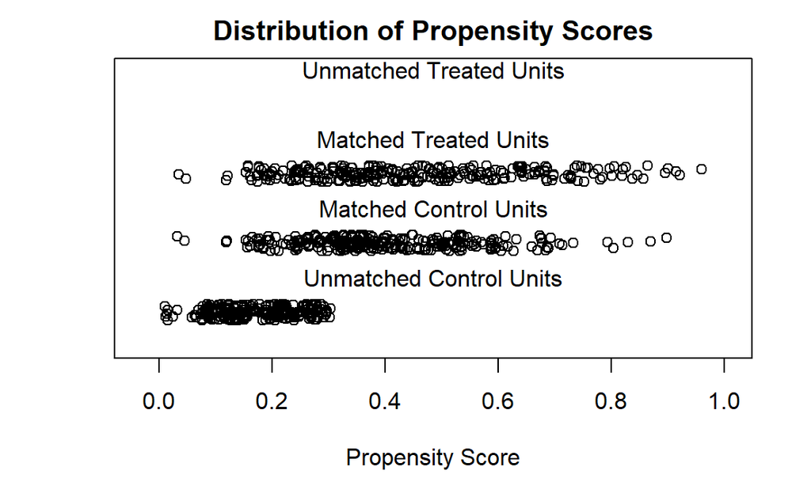

```r
plot(m.out1,type="jitter")
```

#From the above table, we can infer that #Firstly, there are 268 observations which are controlled and treated among 500 observations. Hence, achieved balance.

#Secondly, there are 232 observations that did not have analogue on treated group. i.e, unmatched controlled observations.

#Also, as there are fewer treated observations than controlled observations, the unmatched treated observations are 0.

#From the jitter plot, we can observe that #The dispersion as the whole across the range of values is nearly identical in terms of how they fall in each range of of propensity scores.

```r
#optimal method
library(optmatch)
m.out.2 <- matchit(test ~ bmi+diabetes+pregnant,
                 data = pima,
                 method="optimal")
summary(m.out.2)
```

```
Call:
matchit(formula = test ~ bmi + diabetes + pregnant, data = pima,
    method = "optimal")

Summary of Balance for All Data:
         Means Treated Means Control Std. Mean Diff. Var. Ratio
distance        0.4521        0.2937          0.8208     1.3711
bmi            35.1425       30.3042          0.6662     0.8921
diabetes        0.5505        0.4297          0.3243     1.5500
pregnant        4.8657        3.2980          0.4190     1.5375
         eCDF Mean eCDF Max
distance    0.2380   0.3568
bmi         0.1575   0.3126
diabetes    0.1042   0.1701
pregnant    0.0920   0.2065


Summary of Balance for Matched Data:
         Means Treated Means Control Std. Mean Diff. Var. Ratio
distance        0.4521        0.3989          0.2759     1.6595
bmi            35.1425       33.8996          0.1711     1.1286
diabetes        0.5505        0.4889          0.1655     1.1834
pregnant        4.8657        4.4552          0.1097     1.2116
         eCDF Mean eCDF Max Std. Pair Dist.
distance    0.0510   0.1604          0.2765
bmi         0.0370   0.0970          0.7582
diabetes    0.0535   0.1119          0.9250
pregnant    0.0283   0.0970          0.9315

Sample Sizes:
          Control Treated
All           500     268
Matched       268     268
Unmatched     232       0
Discarded       0       0
```

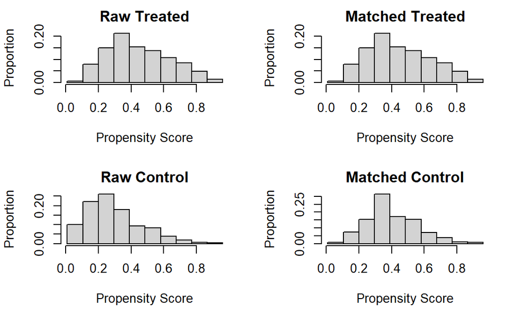

```r
plot(m.out.2, type="hist")
```

#From the histogram plot, we can observe that the observations are evenly distributed.

Q4.

```r
#excluding treatment variable "test"
#install.packages("remotes")
#install.packages(
#"Zelig",repos = "http://r.iq.harvard.edu",type = "source")
library(remotes)
library(Zelig)
z.out <- zelig(glucose ~ bmi+diabetes+pregnant+test,
                 data = match.data(m.out1),
                 model = "ls")
```

```
How to cite this model in Zelig:
  R Core Team. 2007.
  ls: Least Squares Regression for Continuous Dependent Variables
  in Christine Choirat, James Honaker, Kosuke Imai, Gary King, and Olivia Lau,
  "Zelig: Everyone's Statistical Software," http://zeligproject.org/
```

```r
x.out.0 <- setx(z.out, test=0)
x.out.1 <- setx(z.out, test=1)
s.out <- sim(z.out, x = x.out.0, x1 = x.out.1)
summary(s.out)
```

```
 sim x :
 -----
ev
      mean      sd      50%     2.5%    97.5%
1 113.7728 1.76804 113.8511 110.2291 117.0443
pv
         mean       sd     50%     2.5%    97.5%
[1,] 114.4068 29.17215 115.123 55.11831 170.6182

 sim x1 :
 -----
ev
      mean       sd      50%     2.5%    97.5%
1 141.1166 1.848228 141.1471 137.4261 144.6786
pv
         mean       sd      50%     2.5%    97.5%
[1,] 139.9896 29.58526 140.0624 80.35214 196.8159
fd
      mean       sd      50%     2.5%    97.5%
1 27.34384 2.600099 27.33729 22.41643 32.60237
```

#comparing differences between controlled and treated groups with x being when treatment variable is 0 and x1 being treatment variable 1 including treatment variable “test”.

```r
#excluding treatment variable "test"
#install.packages("remotes")
#install.packages(
#"Zelig",repos = "http://r.iq.harvard.edu",type = "source")
library(remotes)
library(Zelig)
z.out <- zelig(glucose ~ bmi+diabetes+pregnant,
                 data = match.data(m.out1),
                 model = "ls")
```

```
How to cite this model in Zelig:
  R Core Team. 2007.
  ls: Least Squares Regression for Continuous Dependent Variables
  in Christine Choirat, James Honaker, Kosuke Imai, Gary King, and Olivia Lau,
  "Zelig: Everyone's Statistical Software," http://zeligproject.org/
```

```r
x.out.0 <- setx(z.out)
x.out.1 <- setx(z.out)
s.out <- sim(z.out, x = x.out.0, x1 = x.out.1)
summary(s.out)
```

```
 sim x :
 -----
ev
      mean       sd      50%     2.5%    97.5%
1 127.2992 1.410525 127.2808 124.6021 130.0062
pv
         mean       sd      50%     2.5%    97.5%
[1,] 127.2107 32.33068 126.6131 65.06821 193.3102

 sim x1 :
 -----
ev
      mean       sd      50%     2.5%    97.5%
1 127.2992 1.410525 127.2808 124.6021 130.0062
pv
         mean       sd      50%     2.5%    97.5%
[1,] 128.5945 31.96066 127.9356 68.04217 192.2748
fd
  mean sd 50% 2.5% 97.5%
1    0  0   0    0     0
```